# Assignment 1 Task 2

### Part 3 Scree Plot

For fun make a screeplot to display the fraction of variance in the data explained by each of the different 6 PC.

```r
# Make a dataframe with the PCA results.
# Used this website https://datavizpyr.com/how-to-make-scree-plot-in-r-with-ggplot2/ as an example.

var_explained_df <- data.frame(PC= paste0("PC",1:6),
                               var_explained=(pca_country_env$sdev)^2/sum((pca_country_env$sdev)^2))

# Look at dataframe.

head(var_explained_df)
```

```
##    PC var_explained
## 1 PC1    0.38676032
## 2 PC2    0.30438069
## 3 PC3    0.15557646
## 4 PC4    0.09113389
## 5 PC5    0.04465521
## 6 PC6    0.01749343
```

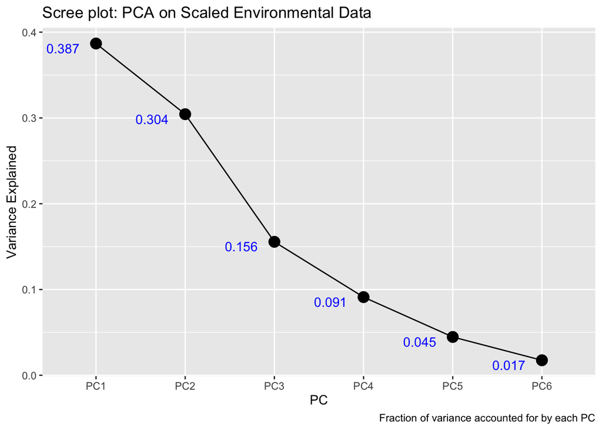

```r
# Make a scree plot using the var_explained_df created above.
# Use both geom_point() and geom_line() to show both lines and points.
# Use geom_text() function to label the points on the graph with the variance explained values set to 3 significant figures.

var_explained_df %>%
  ggplot(aes(x=PC,y=var_explained, group=1))+
  geom_point(size=4)+
  geom_line()+
  labs(title="Scree plot: PCA on Scaled Environmental Data", x = "PC", y = "Variance Explained", caption = "Fraction of variance accounted for by each PC") +
  geom_text(aes(label = sprintf("%.3f", var_explained)), color = "blue", vjust = 1, hjust = 1.5, digits = 4)
```

The graph above is a scree line and point plot that displays the fraction of variance accounted for by each of the six individual PCs. The blue numbers indicate the fraction of variance out of 1 accounted for by that PC. PC 1 accounts for 38.7% of the variance and PC 2 accounts for 30.4% of the variance. Notice, these percentages are the same as the axis labels in the PCA biplot for PC 1 and PC 2. This scree plot allows a way to visualize the remaining PCs variance that do not show up on the biplot and to see how variance is distributed among the different PCs.